# Risk Factor Analysis

## Outcome Variable

**Outcome Variable:** wast_rec90d

## Predictor Variables

**Intervention Variable:** mhtcm

**Adjustment Set:**

- arm
- W_mage
- meducyrs
- feducyrs
- delta_W_mage
- delta_meducyrs
- delta_feducyrs

## Stratifying Variables

The analysis was stratified on these variable(s):

- agecat
- studyid
- country

## Data Summary

| agecat | studyid | country | mhtcm | wast_rec90d | n_cell | n |
| --- | --- | --- | --- | --- | --- | --- |
| 0-24 months | ki0047075b-MAL-ED | BANGLADESH | >=155 cm | 0 | 4 | 122 |
| 0-24 months | ki0047075b-MAL-ED | BANGLADESH | >=155 cm | 1 | 5 | 122 |
| 0-24 months | ki0047075b-MAL-ED | BANGLADESH | <151 cm | 0 | 33 | 122 |
| 0-24 months | ki0047075b-MAL-ED | BANGLADESH | <151 cm | 1 | 51 | 122 |
| 0-24 months | ki0047075b-MAL-ED | BANGLADESH | [151-155) cm | 0 | 7 | 122 |
| 0-24 months | ki0047075b-MAL-ED | BANGLADESH | [151-155) cm | 1 | 22 | 122 |
| 0-24 months | ki0047075b-MAL-ED | BRAZIL | >=155 cm | 0 | 5 | 23 |
| 0-24 months | ki0047075b-MAL-ED | BRAZIL | >=155 cm | 1 | 12 | 23 |
| 0-24 months | ki0047075b-MAL-ED | BRAZIL | <151 cm | 0 | 1 | 23 |
| 0-24 months | ki0047075b-MAL-ED | BRAZIL | <151 cm | 1 | 4 | 23 |
| 0-24 months | ki0047075b-MAL-ED | BRAZIL | [151-155) cm | 0 | 0 | 23 |
| 0-24 months | ki0047075b-MAL-ED | BRAZIL | [151-155) cm | 1 | 1 | 23 |
| 0-24 months | ki0047075b-MAL-ED | INDIA | >=155 cm | 0 | 12 | 175 |
| 0-24 months | ki0047075b-MAL-ED | INDIA | >=155 cm | 1 | 17 | 175 |
| 0-24 months | ki0047075b-MAL-ED | INDIA | <151 cm | 0 | 44 | 175 |
| 0-24 months | ki0047075b-MAL-ED | INDIA | <151 cm | 1 | 49 | 175 |
| 0-24 months | ki0047075b-MAL-ED | INDIA | [151-155) cm | 0 | 14 | 175 |
| 0-24 months | ki0047075b-MAL-ED | INDIA | [151-155) cm | 1 | 39 | 175 |
| 0-24 months | ki0047075b-MAL-ED | NEPAL | >=155 cm | 0 | 3 | 93 |
| 0-24 months | ki0047075b-MAL-ED | NEPAL | >=155 cm | 1 | 6 | 93 |
| 0-24 months | ki0047075b-MAL-ED | NEPAL | <151 cm | 0 | 14 | 93 |
| 0-24 months | ki0047075b-MAL-ED | NEPAL | <151 cm | 1 | 45 | 93 |
| 0-24 months | ki0047075b-MAL-ED | NEPAL | [151-155) cm | 0 | 3 | 93 |
| 0-24 months | ki0047075b-MAL-ED | NEPAL | [151-155) cm | 1 | 22 | 93 |
| 0-24 months | ki0047075b-MAL-ED | PERU | >=155 cm | 0 | 0 | 34 |
| 0-24 months | ki0047075b-MAL-ED | PERU | >=155 cm | 1 | 3 | 34 |
| 0-24 months | ki0047075b-MAL-ED | PERU | <151 cm | 0 | 4 | 34 |
| 0-24 months | ki0047075b-MAL-ED | PERU | <151 cm | 1 | 23 | 34 |
| 0-24 months | ki0047075b-MAL-ED | PERU | [151-155) cm | 0 | 2 | 34 |
| 0-24 months | ki0047075b-MAL-ED | PERU | [151-155) cm | 1 | 2 | 34 |

[output cut: 378 more lines]

The following strata were considered:

- agecat: 0-24 months, studyid: ki0047075b-MAL-ED, country: BANGLADESH
- agecat: 0-24 months, studyid: ki0047075b-MAL-ED, country: BRAZIL
- agecat: 0-24 months, studyid: ki0047075b-MAL-ED, country: INDIA
- agecat: 0-24 months, studyid: ki0047075b-MAL-ED, country: NEPAL
- agecat: 0-24 months, studyid: ki0047075b-MAL-ED, country: PERU
- agecat: 0-24 months, studyid: ki0047075b-MAL-ED, country: SOUTH AFRICA
- agecat: 0-24 months, studyid: ki0047075b-MAL-ED, country: TANZANIA, UNITED REPUBLIC OF
- agecat: 0-24 months, studyid: ki1000304b-SAS-CompFeed, country: INDIA
- agecat: 0-24 months, studyid: ki1000304b-SAS-FoodSuppl, country: INDIA
- agecat: 0-24 months, studyid: ki1017093-NIH-Birth, country: BANGLADESH
- agecat: 0-24 months, studyid: ki1017093b-PROVIDE, country: BANGLADESH
- agecat: 0-24 months, studyid: ki1017093c-NIH-Crypto, country: BANGLADESH
- agecat: 0-24 months, studyid: ki1066203-TanzaniaChild2, country: TANZANIA, UNITED REPUBLIC OF
- agecat: 0-24 months, studyid: ki1101329-Keneba, country: GAMBIA
- agecat: 0-24 months, studyid: ki1112895-Guatemala BSC, country: GUATEMALA
- agecat: 0-24 months, studyid: ki1112895-iLiNS-Zinc, country: BURKINA FASO
- agecat: 0-24 months, studyid: ki1119695-PROBIT, country: BELARUS
- agecat: 0-24 months, studyid: ki1126311-ZVITAMBO, country: ZIMBABWE
- agecat: 0-24 months, studyid: ki1135781-COHORTS, country: GUATEMALA
- agecat: 0-24 months, studyid: ki1135781-COHORTS, country: INDIA
- agecat: 0-24 months, studyid: ki1135781-COHORTS, country: PHILIPPINES
- agecat: 0-24 months, studyid: ki1148112-LCNI-5, country: MALAWI
- agecat: 0-24 months, studyid: kiGH5241-JiVitA-3, country: BANGLADESH
- agecat: 0-6 months, studyid: ki0047075b-MAL-ED, country: BANGLADESH
- agecat: 0-6 months, studyid: ki0047075b-MAL-ED, country: BRAZIL
- agecat: 0-6 months, studyid: ki0047075b-MAL-ED, country: INDIA
- agecat: 0-6 months, studyid: ki0047075b-MAL-ED, country: NEPAL
- agecat: 0-6 months, studyid: ki0047075b-MAL-ED, country: PERU
- agecat: 0-6 months, studyid: ki0047075b-MAL-ED, country: SOUTH AFRICA
- agecat: 0-6 months, studyid: ki0047075b-MAL-ED, country: TANZANIA, UNITED REPUBLIC OF
- agecat: 0-6 months, studyid: ki1000304b-SAS-CompFeed, country: INDIA
- agecat: 0-6 months, studyid: ki1000304b-SAS-FoodSuppl, country: INDIA
- agecat: 0-6 months, studyid: ki1017093-NIH-Birth, country: BANGLADESH
- agecat: 0-6 months, studyid: ki1017093b-PROVIDE, country: BANGLADESH
- agecat: 0-6 months, studyid: ki1017093c-NIH-Crypto, country: BANGLADESH
- agecat: 0-6 months, studyid: ki1066203-TanzaniaChild2, country: TANZANIA, UNITED REPUBLIC OF
- agecat: 0-6 months, studyid: ki1101329-Keneba, country: GAMBIA
- agecat: 0-6 months, studyid: ki1112895-Guatemala BSC, country: GUATEMALA
- agecat: 0-6 months, studyid: ki1119695-PROBIT, country: BELARUS
- agecat: 0-6 months, studyid: ki1126311-ZVITAMBO, country: ZIMBABWE
- agecat: 0-6 months, studyid: ki1135781-COHORTS, country: GUATEMALA
- agecat: 0-6 months, studyid: ki1135781-COHORTS, country: INDIA
- agecat: 0-6 months, studyid: ki1135781-COHORTS, country: PHILIPPINES
- agecat: 0-6 months, studyid: ki1148112-LCNI-5, country: MALAWI
- agecat: 0-6 months, studyid: kiGH5241-JiVitA-3, country: BANGLADESH
- agecat: 6-24 months, studyid: ki0047075b-MAL-ED, country: BANGLADESH
- agecat: 6-24 months, studyid: ki0047075b-MAL-ED, country: BRAZIL
- agecat: 6-24 months, studyid: ki0047075b-MAL-ED, country: INDIA
- agecat: 6-24 months, studyid: ki0047075b-MAL-ED, country: NEPAL
- agecat: 6-24 months, studyid: ki0047075b-MAL-ED, country: PERU
- agecat: 6-24 months, studyid: ki0047075b-MAL-ED, country: SOUTH AFRICA
- agecat: 6-24 months, studyid: ki0047075b-MAL-ED, country: TANZANIA, UNITED REPUBLIC OF
- agecat: 6-24 months, studyid: ki1000304b-SAS-CompFeed, country: INDIA
- agecat: 6-24 months, studyid: ki1000304b-SAS-FoodSuppl, country: INDIA
- agecat: 6-24 months, studyid: ki1017093-NIH-Birth, country: BANGLADESH
- agecat: 6-24 months, studyid: ki1017093b-PROVIDE, country: BANGLADESH
- agecat: 6-24 months, studyid: ki1017093c-NIH-Crypto, country: BANGLADESH
- agecat: 6-24 months, studyid: ki1066203-TanzaniaChild2, country: TANZANIA, UNITED REPUBLIC OF
- agecat: 6-24 months, studyid: ki1101329-Keneba, country: GAMBIA
- agecat: 6-24 months, studyid: ki1112895-Guatemala BSC, country: GUATEMALA
- agecat: 6-24 months, studyid: ki1112895-iLiNS-Zinc, country: BURKINA FASO
- agecat: 6-24 months, studyid: ki1119695-PROBIT, country: BELARUS
- agecat: 6-24 months, studyid: ki1126311-ZVITAMBO, country: ZIMBABWE
- agecat: 6-24 months, studyid: ki1135781-COHORTS, country: GUATEMALA
- agecat: 6-24 months, studyid: ki1135781-COHORTS, country: INDIA
- agecat: 6-24 months, studyid: ki1135781-COHORTS, country: PHILIPPINES
- agecat: 6-24 months, studyid: ki1148112-LCNI-5, country: MALAWI
- agecat: 6-24 months, studyid: kiGH5241-JiVitA-3, country: BANGLADESH

### Dropped Strata

Some strata were dropped due to rare outcomes:

- agecat: 0-24 months, studyid: ki0047075b-MAL-ED, country: BANGLADESH
- agecat: 0-24 months, studyid: ki0047075b-MAL-ED, country: BRAZIL
- agecat: 0-24 months, studyid: ki0047075b-MAL-ED, country: NEPAL
- agecat: 0-24 months, studyid: ki0047075b-MAL-ED, country: PERU
- agecat: 0-24 months, studyid: ki0047075b-MAL-ED, country: SOUTH AFRICA
- agecat: 0-24 months, studyid: ki0047075b-MAL-ED, country: TANZANIA, UNITED REPUBLIC OF
- agecat: 0-24 months, studyid: ki1000304b-SAS-FoodSuppl, country: INDIA
- agecat: 0-24 months, studyid: ki1112895-Guatemala BSC, country: GUATEMALA
- agecat: 0-24 months, studyid: ki1112895-iLiNS-Zinc, country: BURKINA FASO
- agecat: 0-24 months, studyid: ki1119695-PROBIT, country: BELARUS
- agecat: 0-24 months, studyid: ki1148112-LCNI-5, country: MALAWI
- agecat: 0-6 months, studyid: ki0047075b-MAL-ED, country: BANGLADESH
- agecat: 0-6 months, studyid: ki0047075b-MAL-ED, country: BRAZIL
- agecat: 0-6 months, studyid: ki0047075b-MAL-ED, country: INDIA
- agecat: 0-6 months, studyid: ki0047075b-MAL-ED, country: NEPAL
- agecat: 0-6 months, studyid: ki0047075b-MAL-ED, country: PERU
- agecat: 0-6 months, studyid: ki0047075b-MAL-ED, country: SOUTH AFRICA
- agecat: 0-6 months, studyid: ki0047075b-MAL-ED, country: TANZANIA, UNITED REPUBLIC OF
- agecat: 0-6 months, studyid: ki1000304b-SAS-FoodSuppl, country: INDIA
- agecat: 0-6 months, studyid: ki1017093c-NIH-Crypto, country: BANGLADESH
- agecat: 0-6 months, studyid: ki1112895-Guatemala BSC, country: GUATEMALA
- agecat: 0-6 months, studyid: ki1119695-PROBIT, country: BELARUS
- agecat: 0-6 months, studyid: ki1148112-LCNI-5, country: MALAWI
- agecat: 6-24 months, studyid: ki0047075b-MAL-ED, country: BANGLADESH
- agecat: 6-24 months, studyid: ki0047075b-MAL-ED, country: BRAZIL
- agecat: 6-24 months, studyid: ki0047075b-MAL-ED, country: NEPAL
- agecat: 6-24 months, studyid: ki0047075b-MAL-ED, country: PERU
- agecat: 6-24 months, studyid: ki0047075b-MAL-ED, country: SOUTH AFRICA
- agecat: 6-24 months, studyid: ki0047075b-MAL-ED, country: TANZANIA, UNITED REPUBLIC OF
- agecat: 6-24 months, studyid: ki1000304b-SAS-FoodSuppl, country: INDIA
- agecat: 6-24 months, studyid: ki1017093b-PROVIDE, country: BANGLADESH
- agecat: 6-24 months, studyid: ki1017093c-NIH-Crypto, country: BANGLADESH
- agecat: 6-24 months, studyid: ki1112895-Guatemala BSC, country: GUATEMALA
- agecat: 6-24 months, studyid: ki1112895-iLiNS-Zinc, country: BURKINA FASO
- agecat: 6-24 months, studyid: ki1119695-PROBIT, country: BELARUS
- agecat: 6-24 months, studyid: ki1126311-ZVITAMBO, country: ZIMBABWE
- agecat: 6-24 months, studyid: ki1135781-COHORTS, country: GUATEMALA
- agecat: 6-24 months, studyid: ki1135781-COHORTS, country: INDIA
- agecat: 6-24 months, studyid: ki1148112-LCNI-5, country: MALAWI
- agecat: 6-24 months, studyid: kiGH5241-JiVitA-3, country: BANGLADESH

## Methods Detail

We’re interested in the causal parameters $E[Y_a]$ for all values of $a \in \mathcal{A}$. These parameters represent the mean outcome if, possibly contrary to fact, we intervened to set all units to have $A=a$. Under the randomization and positivity assumptions, these are identified by the statistical parameters $\psi_a=E_W[E_{Y|A,W}(Y|A=a,W)]$. In addition, we’re interested in the mean of $Y$, $E[Y]$ under no intervention (the observed mean). We will estimate these parameters by using SuperLearner to fit the relevant likelihood factors – $E_{Y|A,W}(Y|A=a,W)$ and $p(A=a|W)$, and then updating our likelihood fit using a joint TMLE.

For unadjusted analyses ($W=\{\}$), initial likelihoods were estimated using Lrnr_glm to estimate the simple $E(Y|A)$ and Lrnr_mean to estimate $p(A)$. For adjusted analyses, a small library containing Lrnr_glmnet, Lrnr_xgboost, and Lrnr_mean was used.

Having estimated these parameters, we will then use the delta method to estimate relative risks and attributable risks relative to a prespecified baseline level of $A$.

# Results Detail

## Results Plots

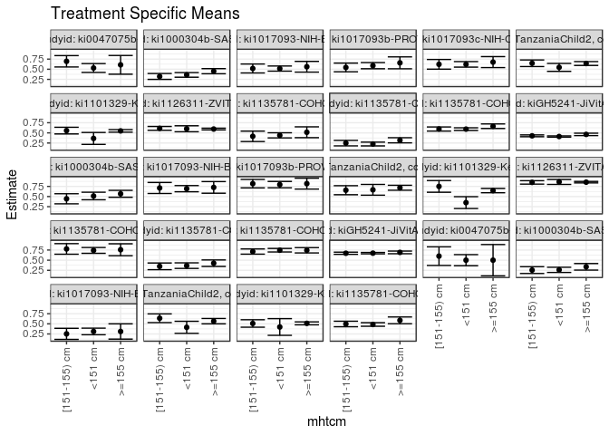

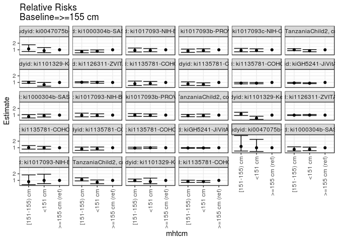

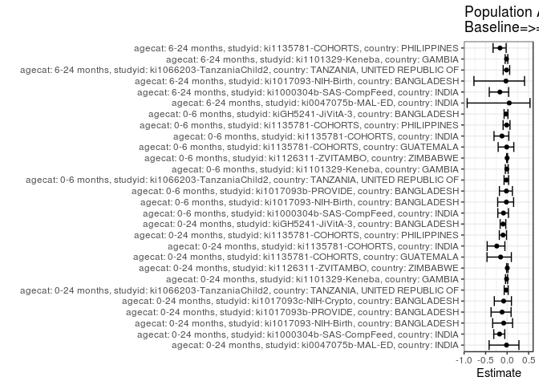

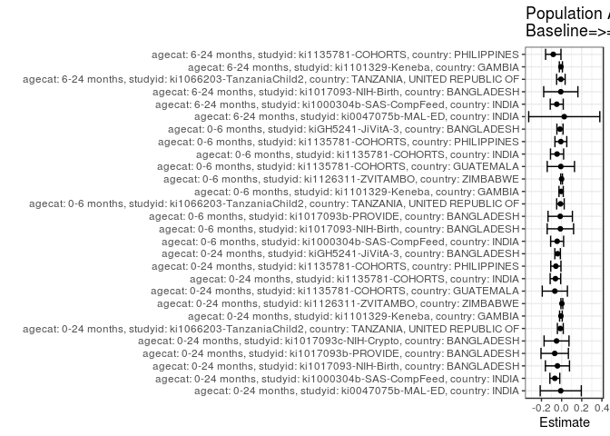

## Results Table

### Parameter: TSM

| agecat | studyid | country | intervention_level | baseline_level | estimate | ci_lower | ci_upper |
| --- | --- | --- | --- | --- | --- | --- | --- |
| 0-24 months | ki0047075b-MAL-ED | INDIA | >=155 cm | NA | 0.6085250 | 0.3776316 | 0.8394184 |
| 0-24 months | ki0047075b-MAL-ED | INDIA | <151 cm | NA | 0.5306609 | 0.4218835 | 0.6394383 |
| 0-24 months | ki0047075b-MAL-ED | INDIA | [151-155) cm | NA | 0.6956413 | 0.5554237 | 0.8358588 |
| 0-24 months | ki1000304b-SAS-CompFeed | INDIA | >=155 cm | NA | 0.4518409 | 0.3886135 | 0.5150682 |
| 0-24 months | ki1000304b-SAS-CompFeed | INDIA | <151 cm | NA | 0.3598877 | 0.3031526 | 0.4166228 |
| 0-24 months | ki1000304b-SAS-CompFeed | INDIA | [151-155) cm | NA | 0.3217291 | 0.2490657 | 0.3943925 |
| 0-24 months | ki1017093-NIH-Birth | BANGLADESH | >=155 cm | NA | 0.5615987 | 0.4291957 | 0.6940017 |
| 0-24 months | ki1017093-NIH-Birth | BANGLADESH | <151 cm | NA | 0.5161669 | 0.4524907 | 0.5798431 |
| 0-24 months | ki1017093-NIH-Birth | BANGLADESH | [151-155) cm | NA | 0.5185295 | 0.4079958 | 0.6290631 |
| 0-24 months | ki1017093b-PROVIDE | BANGLADESH | >=155 cm | NA | 0.6580510 | 0.5107350 | 0.8053669 |
| 0-24 months | ki1017093b-PROVIDE | BANGLADESH | <151 cm | NA | 0.5884617 | 0.5119581 | 0.6649652 |
| 0-24 months | ki1017093b-PROVIDE | BANGLADESH | [151-155) cm | NA | 0.5443908 | 0.4369751 | 0.6518065 |
| 0-24 months | ki1017093c-NIH-Crypto | BANGLADESH | >=155 cm | NA | 0.6761494 | 0.5408286 | 0.8114702 |
| 0-24 months | ki1017093c-NIH-Crypto | BANGLADESH | <151 cm | NA | 0.6203057 | 0.5518959 | 0.6887154 |
| 0-24 months | ki1017093c-NIH-Crypto | BANGLADESH | [151-155) cm | NA | 0.6215244 | 0.5019100 | 0.7411389 |
| 0-24 months | ki1066203-TanzaniaChild2 | TANZANIA, UNITED REPUBLIC OF | >=155 cm | NA | 0.6411387 | 0.5936946 | 0.6885828 |
| 0-24 months | ki1066203-TanzaniaChild2 | TANZANIA, UNITED REPUBLIC OF | <151 cm | NA | 0.5460831 | 0.4478742 | 0.6442919 |
| 0-24 months | ki1066203-TanzaniaChild2 | TANZANIA, UNITED REPUBLIC OF | [151-155) cm | NA | 0.6479850 | 0.5667424 | 0.7292276 |
| 0-24 months | ki1101329-Keneba | GAMBIA | >=155 cm | NA | 0.5489114 | 0.5174266 | 0.5803962 |
| 0-24 months | ki1101329-Keneba | GAMBIA | <151 cm | NA | 0.3634548 | 0.2163118 | 0.5105979 |
| 0-24 months | ki1101329-Keneba | GAMBIA | [151-155) cm | NA | 0.5564286 | 0.4738182 | 0.6390390 |
| 0-24 months | ki1126311-ZVITAMBO | ZIMBABWE | >=155 cm | NA | 0.5946705 | 0.5736004 | 0.6157407 |
| 0-24 months | ki1126311-ZVITAMBO | ZIMBABWE | <151 cm | NA | 0.6015674 | 0.5278153 | 0.6753196 |
| 0-24 months | ki1126311-ZVITAMBO | ZIMBABWE | [151-155) cm | NA | 0.6112506 | 0.5638846 | 0.6586166 |
| 0-24 months | ki1135781-COHORTS | GUATEMALA | >=155 cm | NA | 0.5150334 | 0.3810860 | 0.6489809 |
| 0-24 months | ki1135781-COHORTS | GUATEMALA | <151 cm | NA | 0.4396456 | 0.3763449 | 0.5029462 |
| 0-24 months | ki1135781-COHORTS | GUATEMALA | [151-155) cm | NA | 0.4152060 | 0.2864001 | 0.5440119 |
| 0-24 months | ki1135781-COHORTS | INDIA | >=155 cm | NA | 0.3172225 | 0.2537030 | 0.3807421 |
| 0-24 months | ki1135781-COHORTS | INDIA | <151 cm | NA | 0.2248287 | 0.1782853 | 0.2713720 |
| 0-24 months | ki1135781-COHORTS | INDIA | [151-155) cm | NA | 0.2469004 | 0.1794190 | 0.3143819 |

[output cut: 54 more lines]

### Parameter: E(Y)

| agecat | studyid | country | intervention_level | baseline_level | estimate | ci_lower | ci_upper |
| --- | --- | --- | --- | --- | --- | --- | --- |
| 0-24 months | ki0047075b-MAL-ED | INDIA | NA | NA | 0.6000000 | 0.5192868 | 0.6807132 |
| 0-24 months | ki1000304b-SAS-CompFeed | INDIA | NA | NA | 0.3844086 | 0.3477135 | 0.4211037 |
| 0-24 months | ki1017093-NIH-Birth | BANGLADESH | NA | NA | 0.5201900 | 0.4695846 | 0.5707955 |
| 0-24 months | ki1017093b-PROVIDE | BANGLADESH | NA | NA | 0.5894040 | 0.5323948 | 0.6464131 |
| 0-24 months | ki1017093c-NIH-Crypto | BANGLADESH | NA | NA | 0.6258065 | 0.5718723 | 0.6797406 |
| 0-24 months | ki1066203-TanzaniaChild2 | TANZANIA, UNITED REPUBLIC OF | NA | NA | 0.6283688 | 0.5905159 | 0.6662217 |
| 0-24 months | ki1101329-Keneba | GAMBIA | NA | NA | 0.5422222 | 0.5133413 | 0.5711031 |
| 0-24 months | ki1126311-ZVITAMBO | ZIMBABWE | NA | NA | 0.5971546 | 0.5785503 | 0.6157590 |
| 0-24 months | ki1135781-COHORTS | GUATEMALA | NA | NA | 0.4477212 | 0.3954919 | 0.4999504 |
| 0-24 months | ki1135781-COHORTS | INDIA | NA | NA | 0.2557143 | 0.2227697 | 0.2886589 |
| 0-24 months | ki1135781-COHORTS | PHILIPPINES | NA | NA | 0.6068680 | 0.5823645 | 0.6313715 |
| 0-24 months | kiGH5241-JiVitA-3 | BANGLADESH | NA | NA | 0.4228321 | 0.4116868 | 0.4339775 |
| 0-6 months | ki1000304b-SAS-CompFeed | INDIA | NA | NA | 0.5228758 | 0.4664267 | 0.5793250 |
| 0-6 months | ki1017093-NIH-Birth | BANGLADESH | NA | NA | 0.7130045 | 0.6535890 | 0.7724200 |
| 0-6 months | ki1017093b-PROVIDE | BANGLADESH | NA | NA | 0.8044693 | 0.7471161 | 0.8618224 |
| 0-6 months | ki1066203-TanzaniaChild2 | TANZANIA, UNITED REPUBLIC OF | NA | NA | 0.7053571 | 0.6558827 | 0.7548316 |
| 0-6 months | ki1101329-Keneba | GAMBIA | NA | NA | 0.6415094 | 0.5927496 | 0.6902692 |
| 0-6 months | ki1126311-ZVITAMBO | ZIMBABWE | NA | NA | 0.8543527 | 0.8380828 | 0.8706225 |
| 0-6 months | ki1135781-COHORTS | GUATEMALA | NA | NA | 0.7500000 | 0.6917133 | 0.8082867 |
| 0-6 months | ki1135781-COHORTS | INDIA | NA | NA | 0.3800425 | 0.3361595 | 0.4239255 |
| 0-6 months | ki1135781-COHORTS | PHILIPPINES | NA | NA | 0.7367021 | 0.7051294 | 0.7682749 |
| 0-6 months | kiGH5241-JiVitA-3 | BANGLADESH | NA | NA | 0.6759220 | 0.6625668 | 0.6892772 |
| 6-24 months | ki0047075b-MAL-ED | INDIA | NA | NA | 0.5263158 | 0.4116286 | 0.6410029 |
| 6-24 months | ki1000304b-SAS-CompFeed | INDIA | NA | NA | 0.2876712 | 0.2441703 | 0.3311721 |
| 6-24 months | ki1017093-NIH-Birth | BANGLADESH | NA | NA | 0.3030303 | 0.2377927 | 0.3682679 |
| 6-24 months | ki1066203-TanzaniaChild2 | TANZANIA, UNITED REPUBLIC OF | NA | NA | 0.5582656 | 0.5057575 | 0.6107737 |
| 6-24 months | ki1101329-Keneba | GAMBIA | NA | NA | 0.5045965 | 0.4711801 | 0.5380129 |
| 6-24 months | ki1135781-COHORTS | PHILIPPINES | NA | NA | 0.5026681 | 0.4688378 | 0.5364984 |

### Parameter: RR

| agecat | studyid | country | intervention_level | baseline_level | estimate | ci_lower | ci_upper |
| --- | --- | --- | --- | --- | --- | --- | --- |
| 0-24 months | ki0047075b-MAL-ED | INDIA | >=155 cm | >=155 cm | 1.0000000 | 1.0000000 | 1.0000000 |
| 0-24 months | ki0047075b-MAL-ED | INDIA | <151 cm | >=155 cm | 0.8720445 | 0.5661883 | 1.3431248 |
| 0-24 months | ki0047075b-MAL-ED | INDIA | [151-155) cm | >=155 cm | 1.1431596 | 0.7442541 | 1.7558707 |
| 0-24 months | ki1000304b-SAS-CompFeed | INDIA | >=155 cm | >=155 cm | 1.0000000 | 1.0000000 | 1.0000000 |
| 0-24 months | ki1000304b-SAS-CompFeed | INDIA | <151 cm | >=155 cm | 0.7964922 | 0.6450974 | 0.9834170 |
| 0-24 months | ki1000304b-SAS-CompFeed | INDIA | [151-155) cm | >=155 cm | 0.7120408 | 0.5459166 | 0.9287172 |
| 0-24 months | ki1017093-NIH-Birth | BANGLADESH | >=155 cm | >=155 cm | 1.0000000 | 1.0000000 | 1.0000000 |
| 0-24 months | ki1017093-NIH-Birth | BANGLADESH | <151 cm | >=155 cm | 0.9191027 | 0.7042412 | 1.1995177 |
| 0-24 months | ki1017093-NIH-Birth | BANGLADESH | [151-155) cm | >=155 cm | 0.9233095 | 0.6716491 | 1.2692647 |
| 0-24 months | ki1017093b-PROVIDE | BANGLADESH | >=155 cm | >=155 cm | 1.0000000 | 1.0000000 | 1.0000000 |
| 0-24 months | ki1017093b-PROVIDE | BANGLADESH | <151 cm | >=155 cm | 0.8942493 | 0.6898744 | 1.1591702 |
| 0-24 months | ki1017093b-PROVIDE | BANGLADESH | [151-155) cm | >=155 cm | 0.8272776 | 0.6136410 | 1.1152908 |
| 0-24 months | ki1017093c-NIH-Crypto | BANGLADESH | >=155 cm | >=155 cm | 1.0000000 | 1.0000000 | 1.0000000 |
| 0-24 months | ki1017093c-NIH-Crypto | BANGLADESH | <151 cm | >=155 cm | 0.9174092 | 0.7296852 | 1.1534283 |
| 0-24 months | ki1017093c-NIH-Crypto | BANGLADESH | [151-155) cm | >=155 cm | 0.9192116 | 0.6961955 | 1.2136677 |
| 0-24 months | ki1066203-TanzaniaChild2 | TANZANIA, UNITED REPUBLIC OF | >=155 cm | >=155 cm | 1.0000000 | 1.0000000 | 1.0000000 |
| 0-24 months | ki1066203-TanzaniaChild2 | TANZANIA, UNITED REPUBLIC OF | <151 cm | >=155 cm | 0.8517393 | 0.7012273 | 1.0345574 |
| 0-24 months | ki1066203-TanzaniaChild2 | TANZANIA, UNITED REPUBLIC OF | [151-155) cm | >=155 cm | 1.0106783 | 0.8736155 | 1.1692450 |
| 0-24 months | ki1101329-Keneba | GAMBIA | >=155 cm | >=155 cm | 1.0000000 | 1.0000000 | 1.0000000 |
| 0-24 months | ki1101329-Keneba | GAMBIA | <151 cm | >=155 cm | 0.6621375 | 0.4399270 | 0.9965883 |
| 0-24 months | ki1101329-Keneba | GAMBIA | [151-155) cm | >=155 cm | 1.0136947 | 0.8644979 | 1.1886402 |
| 0-24 months | ki1126311-ZVITAMBO | ZIMBABWE | >=155 cm | >=155 cm | 1.0000000 | 1.0000000 | 1.0000000 |
| 0-24 months | ki1126311-ZVITAMBO | ZIMBABWE | <151 cm | >=155 cm | 1.0115979 | 0.8903822 | 1.1493157 |
| 0-24 months | ki1126311-ZVITAMBO | ZIMBABWE | [151-155) cm | >=155 cm | 1.0278812 | 0.9438905 | 1.1193456 |
| 0-24 months | ki1135781-COHORTS | GUATEMALA | >=155 cm | >=155 cm | 1.0000000 | 1.0000000 | 1.0000000 |
| 0-24 months | ki1135781-COHORTS | GUATEMALA | <151 cm | >=155 cm | 0.8536253 | 0.6347263 | 1.1480163 |
| 0-24 months | ki1135781-COHORTS | GUATEMALA | [151-155) cm | >=155 cm | 0.8061730 | 0.5381852 | 1.2076047 |
| 0-24 months | ki1135781-COHORTS | INDIA | >=155 cm | >=155 cm | 1.0000000 | 1.0000000 | 1.0000000 |
| 0-24 months | ki1135781-COHORTS | INDIA | <151 cm | >=155 cm | 0.7087412 | 0.5314598 | 0.9451592 |
| 0-24 months | ki1135781-COHORTS | INDIA | [151-155) cm | >=155 cm | 0.7783193 | 0.5544814 | 1.0925182 |

[output cut: 54 more lines]

### Parameter: PAR

| agecat | studyid | country | intervention_level | baseline_level | estimate | ci_lower | ci_upper |
| --- | --- | --- | --- | --- | --- | --- | --- |
| 0-24 months | ki0047075b-MAL-ED | INDIA | >=155 cm | NA | -0.0085250 | -0.2128108 | 0.1957607 |
| 0-24 months | ki1000304b-SAS-CompFeed | INDIA | >=155 cm | NA | -0.0674323 | -0.1165369 | -0.0183276 |
| 0-24 months | ki1017093-NIH-Birth | BANGLADESH | >=155 cm | NA | -0.0414087 | -0.1611193 | 0.0783019 |
| 0-24 months | ki1017093b-PROVIDE | BANGLADESH | >=155 cm | NA | -0.0686470 | -0.2046522 | 0.0673582 |
| 0-24 months | ki1017093c-NIH-Crypto | BANGLADESH | >=155 cm | NA | -0.0503430 | -0.1740979 | 0.0734120 |
| 0-24 months | ki1066203-TanzaniaChild2 | TANZANIA, UNITED REPUBLIC OF | >=155 cm | NA | -0.0127699 | -0.0419430 | 0.0164031 |
| 0-24 months | ki1101329-Keneba | GAMBIA | >=155 cm | NA | -0.0066892 | -0.0199518 | 0.0065734 |
| 0-24 months | ki1126311-ZVITAMBO | ZIMBABWE | >=155 cm | NA | 0.0024841 | -0.0070226 | 0.0119908 |
| 0-24 months | ki1135781-COHORTS | GUATEMALA | >=155 cm | NA | -0.0673122 | -0.1922366 | 0.0576122 |
| 0-24 months | ki1135781-COHORTS | INDIA | >=155 cm | NA | -0.0615082 | -0.1137988 | -0.0092177 |
| 0-24 months | ki1135781-COHORTS | PHILIPPINES | >=155 cm | NA | -0.0573030 | -0.1079205 | -0.0066855 |
| 0-24 months | kiGH5241-JiVitA-3 | BANGLADESH | >=155 cm | NA | -0.0399768 | -0.0674251 | -0.0125284 |
| 0-6 months | ki1000304b-SAS-CompFeed | INDIA | >=155 cm | NA | -0.0445331 | -0.1090045 | 0.0199383 |
| 0-6 months | ki1017093-NIH-Birth | BANGLADESH | >=155 cm | NA | -0.0122788 | -0.1434693 | 0.1189117 |
| 0-6 months | ki1017093b-PROVIDE | BANGLADESH | >=155 cm | NA | -0.0137125 | -0.1347982 | 0.1073731 |
| 0-6 months | ki1066203-TanzaniaChild2 | TANZANIA, UNITED REPUBLIC OF | >=155 cm | NA | -0.0116635 | -0.0490179 | 0.0256909 |
| 0-6 months | ki1101329-Keneba | GAMBIA | >=155 cm | NA | -0.0047928 | -0.0259744 | 0.0163887 |
| 0-6 months | ki1126311-ZVITAMBO | ZIMBABWE | >=155 cm | NA | -0.0001449 | -0.0087162 | 0.0084264 |
| 0-6 months | ki1135781-COHORTS | GUATEMALA | >=155 cm | NA | -0.0075758 | -0.1429684 | 0.1278169 |
| 0-6 months | ki1135781-COHORTS | INDIA | >=155 cm | NA | -0.0453586 | -0.1105783 | 0.0198611 |
| 0-6 months | ki1135781-COHORTS | PHILIPPINES | >=155 cm | NA | -0.0074313 | -0.0662506 | 0.0513881 |
| 0-6 months | kiGH5241-JiVitA-3 | BANGLADESH | >=155 cm | NA | -0.0163938 | -0.0468793 | 0.0140918 |
| 6-24 months | ki0047075b-MAL-ED | INDIA | >=155 cm | NA | 0.0263158 | -0.3268414 | 0.3794730 |
| 6-24 months | ki1000304b-SAS-CompFeed | INDIA | >=155 cm | NA | -0.0482975 | -0.1130084 | 0.0164134 |
| 6-24 months | ki1017093-NIH-Birth | BANGLADESH | >=155 cm | NA | -0.0081891 | -0.1780302 | 0.1616521 |
| 6-24 months | ki1066203-TanzaniaChild2 | TANZANIA, UNITED REPUBLIC OF | >=155 cm | NA | -0.0073283 | -0.0495512 | 0.0348945 |
| 6-24 months | ki1101329-Keneba | GAMBIA | >=155 cm | NA | -0.0070720 | -0.0225243 | 0.0083803 |
| 6-24 months | ki1135781-COHORTS | PHILIPPINES | >=155 cm | NA | -0.0828539 | -0.1591659 | -0.0065419 |

### Parameter: PAF

| agecat | studyid | country | intervention_level | baseline_level | estimate | ci_lower | ci_upper |
| --- | --- | --- | --- | --- | --- | --- | --- |
| 0-24 months | ki0047075b-MAL-ED | INDIA | >=155 cm | NA | -0.0142084 | -0.4184015 | 0.2748043 |
| 0-24 months | ki1000304b-SAS-CompFeed | INDIA | >=155 cm | NA | -0.1754182 | -0.3103394 | -0.0543893 |
| 0-24 months | ki1017093-NIH-Birth | BANGLADESH | >=155 cm | NA | -0.0796030 | -0.3357542 | 0.1274273 |
| 0-24 months | ki1017093b-PROVIDE | BANGLADESH | >=155 cm | NA | -0.1164685 | -0.3731744 | 0.0922479 |
| 0-24 months | ki1017093c-NIH-Crypto | BANGLADESH | >=155 cm | NA | -0.0804449 | -0.2975429 | 0.1003294 |
| 0-24 months | ki1066203-TanzaniaChild2 | TANZANIA, UNITED REPUBLIC OF | >=155 cm | NA | -0.0203223 | -0.0678575 | 0.0250968 |
| 0-24 months | ki1101329-Keneba | GAMBIA | >=155 cm | NA | -0.0123366 | -0.0371196 | 0.0118542 |
| 0-24 months | ki1126311-ZVITAMBO | ZIMBABWE | >=155 cm | NA | 0.0041599 | -0.0118913 | 0.0199565 |
| 0-24 months | ki1135781-COHORTS | GUATEMALA | >=155 cm | NA | -0.1503441 | -0.4674886 | 0.0982612 |
| 0-24 months | ki1135781-COHORTS | INDIA | >=155 cm | NA | -0.2405351 | -0.4633299 | -0.0516611 |
| 0-24 months | ki1135781-COHORTS | PHILIPPINES | >=155 cm | NA | -0.0944242 | -0.1811753 | -0.0140444 |
| 0-24 months | kiGH5241-JiVitA-3 | BANGLADESH | >=155 cm | NA | -0.0945453 | -0.1614214 | -0.0315200 |
| 0-6 months | ki1000304b-SAS-CompFeed | INDIA | >=155 cm | NA | -0.0851696 | -0.2162084 | 0.0317506 |
| 0-6 months | ki1017093-NIH-Birth | BANGLADESH | >=155 cm | NA | -0.0172212 | -0.2189356 | 0.1511127 |
| 0-6 months | ki1017093b-PROVIDE | BANGLADESH | >=155 cm | NA | -0.0170455 | -0.1792690 | 0.1228621 |
| 0-6 months | ki1066203-TanzaniaChild2 | TANZANIA, UNITED REPUBLIC OF | >=155 cm | NA | -0.0165356 | -0.0709389 | 0.0351040 |
| 0-6 months | ki1101329-Keneba | GAMBIA | >=155 cm | NA | -0.0074712 | -0.0410345 | 0.0250101 |
| 0-6 months | ki1126311-ZVITAMBO | ZIMBABWE | >=155 cm | NA | -0.0001696 | -0.0102526 | 0.0098128 |
| 0-6 months | ki1135781-COHORTS | GUATEMALA | >=155 cm | NA | -0.0101010 | -0.2077661 | 0.1552139 |
| 0-6 months | ki1135781-COHORTS | INDIA | >=155 cm | NA | -0.1193514 | -0.3048090 | 0.0397463 |
| 0-6 months | ki1135781-COHORTS | PHILIPPINES | >=155 cm | NA | -0.0100872 | -0.0931856 | 0.0666945 |
| 0-6 months | kiGH5241-JiVitA-3 | BANGLADESH | >=155 cm | NA | -0.0242539 | -0.0703725 | 0.0198775 |
| 6-24 months | ki0047075b-MAL-ED | INDIA | >=155 cm | NA | 0.0500000 | -0.9284701 | 0.5320125 |
| 6-24 months | ki1000304b-SAS-CompFeed | INDIA | >=155 cm | NA | -0.1678912 | -0.4149488 | 0.0360289 |
| 6-24 months | ki1017093-NIH-Birth | BANGLADESH | >=155 cm | NA | -0.0270239 | -0.7714239 | 0.4045592 |
| 6-24 months | ki1066203-TanzaniaChild2 | TANZANIA, UNITED REPUBLIC OF | >=155 cm | NA | -0.0131270 | -0.0917160 | 0.0598047 |
| 6-24 months | ki1101329-Keneba | GAMBIA | >=155 cm | NA | -0.0140151 | -0.0451401 | 0.0161830 |
| 6-24 months | ki1135781-COHORTS | PHILIPPINES | >=155 cm | NA | -0.1648283 | -0.3272529 | -0.0222806 |